# Fig4 script

Valentin Greigert

2023-06-23

# 1 Introduction

# 2 R packages used

A variety of R packages was used for this analysis. All graphics and data wrangling were handled using the [tidyverse suite of packages](https://www.tidyverse.org/). All packages used are available from the Comprehensive R Archive Network (CRAN), Bioconductor.org, or Github.

# 3 Parasite growth

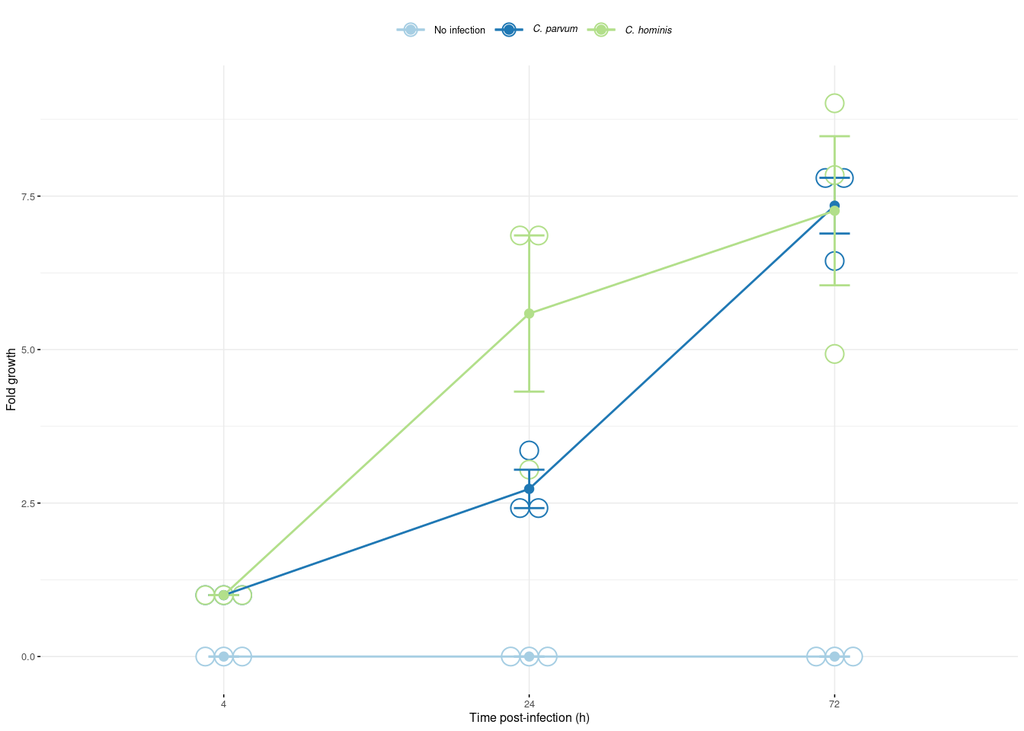

```r
library(tidyverse)
library(ggplot2)
library(RColorBrewer)
library(ggpubr)

growth_dat <- read.csv(file = 'fig4_growth_res.csv')
growth_dat$time <- as.factor(growth_dat$time)
growth_dat$species <- factor(growth_dat$species,
                      level = c('No infection', 'C. parvum', 'C. hominis'))
growth_dat$rep <- as.factor(growth_dat$rep)

growth_plot <- ggline(
  growth_dat,
  'time',
  'fold',
  color = 'species',
  add = c('mean_se', 'dotplot'),
  xlab = 'Time post-infection (h)',
  ylab = 'Fold growth',
  legend.title = '',
  ggtheme = theme_minimal(base_size = 6)
) %>%
  ggpar(legend = 'top') +
  scale_color_brewer(labels = c(
    "No infection",
    expression(paste(italic("C. parvum"))),
    expression(paste(italic("C. hominis")))),
    palette = "Paired"
  )

print(growth_plot)
```

# 4 Read mapping

## 4.1 Aligning raw reads with Kallisto

Raw reads were mapped to the human reference transcriptome using [Kallisto](https://pachterlab.github.io/kallisto/), version 0.46.0. The quality of raw reads, as well as the results of Kallisto mapping are summarized in [this summary report](http://DIYtranscriptomics.github.io/Data/files/multiqc_report.html) generated using [fastqc](https://www.bioinformatics.babraham.ac.uk/projects/fastqc/) and [multiqc](https://multiqc.info/).

## 4.2 Importing count data into R

After read mapping with Kallisto, [TxImport](https://bioconductor.org/packages/release/bioc/html/tximport.html) was used to read kallisto outputs into the R environment. Annotation data from Biomart was used to summarize data from transcript-level to gene-level.

```r
library(tidyverse) # provides access to Hadley Wickham's collection of R packages for data science, which we will use throughout the course
library(tximport) # package for getting Kallisto results into R
library(ensembldb) #helps deal with ensembl
library(EnsDb.Hsapiens.v86) #replace with your organism-specific database package

targets <- read_tsv("study_design.txt")# read in your study design
targets <- subset(targets, timepoint == 24) %>%
  subset(infection != 'Ch')
path <- file.path(targets$id, "abundance.tsv") # set file paths to your mapped data
tx <- transcripts(EnsDb.Hsapiens.v86, columns = c("tx_id", "gene_name"))
tx <- as_tibble(tx)
tx <- dplyr::rename(tx, target_id = tx_id) #change column name
tx <- dplyr::select(tx, "target_id", "gene_name") #transcrip ID needs to be the first column in the dataframe
tx_gene <- tximport(
  path,
  type = "kallisto",
  tx2gene = tx,
  txOut = FALSE,  #determines whether your data represented at transcript or gene level
  countsFromAbundance = "lengthScaledTPM",
  ignoreTxVersion = TRUE
)
```

# 5 Preprocessing

## 5.1 Impact of filtering and normalization

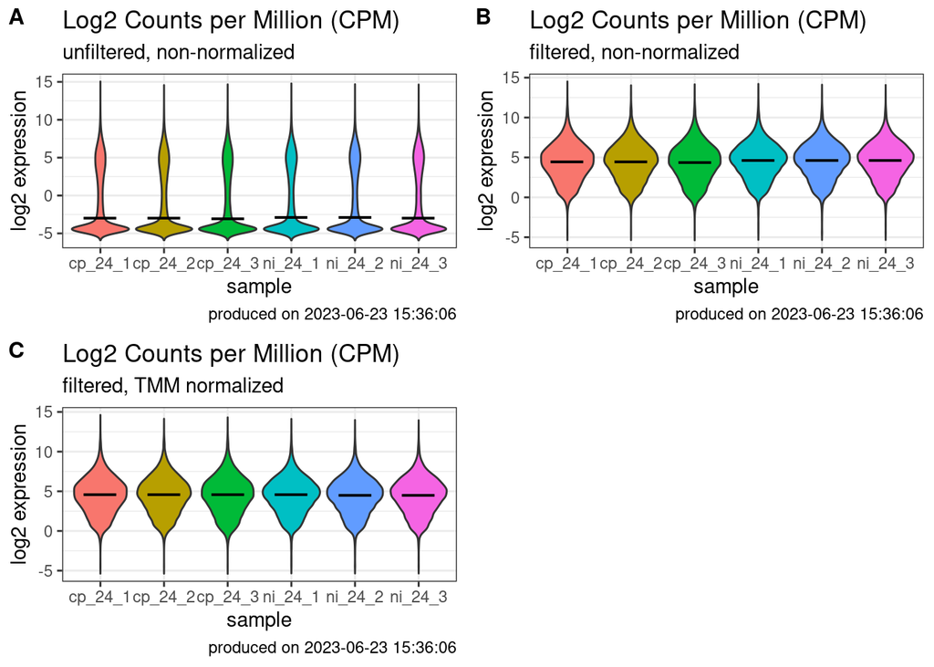

```r
library(tidyverse)
library(edgeR)
library(matrixStats)
library(cowplot)

#additioning technical replicates results
tx_gene$abundance[, 1] <-  tx_gene$abundance[, 1] + tx_gene$abundance[, 7]
tx_gene$abundance[, 2] <-  tx_gene$abundance[, 2] + tx_gene$abundance[, 8]
tx_gene$abundance[, 3] <-  tx_gene$abundance[, 3] + tx_gene$abundance[, 9]
tx_gene$abundance[, 4] <-  tx_gene$abundance[, 4] + tx_gene$abundance[, 10]
tx_gene$abundance[, 5] <-  tx_gene$abundance[, 5] + tx_gene$abundance[, 11]
tx_gene$abundance[, 6] <-  tx_gene$abundance[, 6] + tx_gene$abundance[, 12]

tx_gene$abundance <- tx_gene$abundance[, 1:6]

tx_gene$counts[, 1] <- tx_gene$counts[, 1] + tx_gene$counts[, 7]
tx_gene$counts[, 2] <- tx_gene$counts[, 2] + tx_gene$counts[, 8]
tx_gene$counts[, 3] <- tx_gene$counts[, 3] + tx_gene$counts[, 9]
tx_gene$counts[, 4] <- tx_gene$counts[, 4] + tx_gene$counts[, 10]
tx_gene$counts[, 5] <- tx_gene$counts[, 5] + tx_gene$counts[, 11]
tx_gene$counts[, 6] <- tx_gene$counts[, 6] + tx_gene$counts[, 12]

tx_gene$counts <- tx_gene$counts[, 1:6]

sampleLabels <- c("ni_24_1","cp_24_1","ni_24_2","cp_24_2","ni_24_3","cp_24_3")
DGEList <- DGEList(tx_gene$counts)
log2.cpm <- cpm(DGEList, log=TRUE)

log2.cpm.df <- as_tibble(log2.cpm, rownames = "geneID")
colnames(log2.cpm.df) <- c("geneID", sampleLabels)
log2.cpm.df.pivot <- pivot_longer(log2.cpm.df, # dataframe to be pivoted
                                  cols = 2:7, # column names to be stored as a SINGLE variable
                                  names_to = "samples", # name of that new variable (column)
                                  values_to = "expression") # name of new variable (column) storing all the values (data)

p1 <- ggplot(log2.cpm.df.pivot) +
  aes(x=samples, y=expression, fill=samples) +
  geom_violin(trim = FALSE, show.legend = FALSE) +
  stat_summary(fun = "median",
               geom = "point",
               shape = 95,
               size = 10,
               color = "black",
               show.legend = FALSE) +
  labs(y="log2 expression", x = "sample",
       title="Log2 Counts per Million (CPM)",
       subtitle="unfiltered, non-normalized",
       caption=paste0("produced on ", Sys.time())) +
  theme_bw()

cpm <- cpm(DGEList)
keepers <- rowSums(cpm>1)>=3 #user defined
DGEList.filtered <- DGEList[keepers,]

log2.cpm.filtered <- cpm(DGEList.filtered, log=TRUE)
log2.cpm.filtered.df <- as_tibble(log2.cpm.filtered, rownames = "geneID")
colnames(log2.cpm.filtered.df) <- c("geneID", sampleLabels)
log2.cpm.filtered.df.pivot <- pivot_longer(log2.cpm.filtered.df, # dataframe to be pivoted
                                           cols = 2:7, # column names to be stored as a SINGLE variable
                                           names_to = "samples", # name of that new variable (column)
                                           values_to = "expression") # name of new variable (column) storing all the values (data)

p2 <- ggplot(log2.cpm.filtered.df.pivot) +
  aes(x=samples, y=expression, fill=samples) +
  geom_violin(trim = FALSE, show.legend = FALSE) +
  stat_summary(fun = "median",
               geom = "point",
               shape = 95,
               size = 10,
               color = "black",
               show.legend = FALSE) +
  labs(y="log2 expression", x = "sample",
       title="Log2 Counts per Million (CPM)",
       subtitle="filtered, non-normalized",
       caption=paste0("produced on ", Sys.time())) +
  theme_bw()

DGEList.filtered.norm <- calcNormFactors(DGEList.filtered, method = "TMM")
log2.cpm.filtered.norm <- cpm(DGEList.filtered.norm, log=TRUE)
log2.cpm.filtered.norm.df <- as_tibble(log2.cpm.filtered.norm, rownames = "geneID")
colnames(log2.cpm.filtered.norm.df) <- c("geneID", sampleLabels)
log2.cpm.filtered.norm.df.pivot <- pivot_longer(log2.cpm.filtered.norm.df, # dataframe to be pivoted
                                                cols = 2:7, # column names to be stored as a SINGLE variable
                                                names_to = "samples", # name of that new variable (column)
                                                values_to = "expression") # name of new variable (column) storing all the values (data)

p3 <- ggplot(log2.cpm.filtered.norm.df.pivot) +
  aes(x=samples, y=expression, fill=samples) +
  geom_violin(trim = FALSE, show.legend = FALSE) +
  stat_summary(fun = "median",
               geom = "point",
               shape = 95,
               size = 10,
               color = "black",
               show.legend = FALSE) +
  labs(y="log2 expression", x = "sample",
       title="Log2 Counts per Million (CPM)",
       subtitle="filtered, TMM normalized",
       caption=paste0("produced on ", Sys.time())) +
  theme_bw()

plot_grid(p1, p2, p3, labels = c('A', 'B', 'C'), label_size = 12)
```

## 5.2 table of filtered and normalized data

```r
library(tidyverse)
library(DT)
library(gt)
library(plotly)

data.df <- mutate(
  log2.cpm.filtered.norm.df,
  NI.AVG = (ni_24_1 + ni_24_2 + ni_24_3) / 3,
  Cp.AVG = (cp_24_1 + cp_24_2 + cp_24_3) / 3,
  LogFC = (Cp.AVG - NI.AVG)
) %>%
  mutate_if(is.numeric, round, 2)

datatable(data.df[,c(1,8:10)],
          extensions = c('KeyTable', "FixedHeader"),
          filter = 'top',
          options = list(keys = TRUE,
                         searchHighlight = TRUE,
                         pageLength = 10,
                         lengthMenu = c("10", "25", "50", "100")))
```

|  | geneID | NI.AVG | Cp.AVG | LogFC |
| --- | --- | --- | --- | --- |
| 1 | A1BG | 1.7 | 1.68 | -0.02 |
| 2 | A1CF | 2.41 | 1.09 | -1.32 |
| 3 | A2M | 2.02 | 1.83 | -0.19 |
| 4 | A4GALT | 2.33 | 3.07 | 0.75 |
| 5 | AAAS | 4.7 | 4.42 | -0.28 |
| 6 | AACS | 5.75 | 5.64 | -0.11 |
| 7 | AADAT | 1.53 | 1.19 | -0.35 |
| 8 | AAED1 | 2.64 | 3.27 | 0.63 |
| 9 | AAGAB | 5.6 | 5.71 | 0.11 |
| 10 | AAK1 | 6.85 | 6.94 | 0.09 |

[output cut: 14016 more lines]

The table shown below includes expression data for 14026 genes. You can sort and search the data directly from the table.

# 6 PCA plot

```r
group <- subset(targets, tech_rep == 1)$group %>% as.factor()

pca.res <- prcomp(t(log2.cpm.filtered.norm), scale.=F, retx=T)
pc.var<-pca.res$sdev^2 # sdev^2 captures these eigenvalues from the PCA result
pc.per<-round(pc.var/sum(pc.var)*100, 1)
pca.res.df <- as_tibble(pca.res$x)
pca.plot <- ggplot(pca.res.df) +
  aes(x=PC1, y=PC2, label=sampleLabels, color = group) +
  geom_point(size=4) +
  stat_ellipse() +
  xlab(paste0("PC1 (",pc.per[1],"%",")")) +
  ylab(paste0("PC2 (",pc.per[2],"%",")")) +
  labs(title="PCA plot",
       caption=paste0("produced on ", Sys.time())) +
  coord_fixed() +
  theme_bw()

ggplotly(pca.plot)
```

[interactive chart not shown]

# 7 Volcano plot

```r
library(tidyverse)
library(limma)
library(edgeR)
library(gt)
library(DT)
library(plotly)

infection <- factor(targets$infection[1:6])
design <- model.matrix(~0 + infection)
colnames(design) <- levels(infection)

v.DEGList.filtered.norm <-  voom(DGEList.filtered.norm, design, plot = FALSE)
fit <- lmFit(v.DEGList.filtered.norm, design)
contrast.matrix <- makeContrasts(Cp = Cp - NI,
                                 NI = NI - Cp,
                                 levels = design)

fits <- contrasts.fit(fit, contrast.matrix)
ebFit <- eBayes(fits)
TopHits <- topTable(ebFit, adjust ="BH", coef=1, number=40000, sort.by="logFC")

TopHits.df <- TopHits %>%
  as_tibble(rownames = "geneID")

vplot <- ggplot(TopHits.df) +
  aes(y=-log10(adj.P.Val), x=logFC, text = paste("Symbol:", geneID)) +
  geom_point(size=2) +
  geom_hline(yintercept = -log10(0.01), linetype="longdash", colour="grey", size=1) +
  geom_vline(xintercept = 1, linetype="longdash", colour="#BE684D", size=1) +
  geom_vline(xintercept = -1, linetype="longdash", colour="#2C467A", size=1) +
  #annotate("rect", xmin = 1, xmax = 12, ymin = -log10(0.01), ymax = 7.5, alpha=.2, fill="#BE684D") +
  #annotate("rect", xmin = -1, xmax = -12, ymin = -log10(0.01), ymax = 7.5, alpha=.2, fill="#2C467A") +
  labs(title="Volcano plot",
       subtitle = "Cutaneous leishmaniasis",
       caption=paste0("produced on ", Sys.time())) +
  theme_bw()

ggplotly(vplot)
```

[interactive chart not shown]

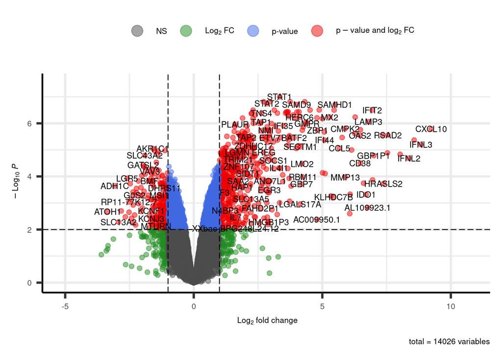

```r
library(EnhancedVolcano)

# using the EnhancedVolcano package
volcano <- EnhancedVolcano(
  toptable = TopHits,
  ylim = c(0, 7.5),
  lab = rownames(TopHits),
  x = 'logFC',
  y = 'adj.P.Val',
  pCutoff = 0.01,
  FCcutoff = 1,
  title = NULL,
  subtitle = NULL,
  labSize = 3,
  axisLabSize = 8,
  legendLabSize = 8,
  captionLabSize = 8,
) %>%
  print()
```

# 8 Table of DEGs

```r
results <- decideTests(ebFit, method="global", adjust.method="BH", p.value=0.05, lfc=1)
colnames(v.DEGList.filtered.norm$E) <- sampleLabels
diffGenes <- v.DEGList.filtered.norm$E[results[,1] !=0,]
diffGenes.df <- as_tibble(diffGenes, rownames = "geneID")
datatable(diffGenes.df,
          extensions = c('KeyTable', "FixedHeader"),
          caption = 'Table 1: DEGs in cutaneous leishmaniasis',
          options = list(keys = TRUE, searchHighlight = TRUE, pageLength = 10, lengthMenu = c("10", "25", "50", "100"))) %>%
  formatRound(columns=c(2:11), digits=2)
```

|  | geneID | ni_24_1 | cp_24_1 | ni_24_2 | cp_24_2 | ni_24_3 | cp_24_3 |
| --- | --- | --- | --- | --- | --- | --- | --- |
| 1 | A1CF | 2.034585497721533 | 0.9544720810044841 | 2.565883162122947 | 1.437136853144303 | 2.586699193189996 | 0.8022777139803561 |
| 2 | AATK | 3.642692966112779 | 1.132214637407496 | 3.829414706071149 | 1.878040910691476 | 4.389654645318595 | 1.523445462152144 |
| 3 | ABC14-864958H18.2 | -0.1922993191370657 | 0.9392182186921557 | 0.2254835275245255 | 0.865909998532054 | -0.671366135526836 | 0.5553596578200305 |
| 4 | ABCA3 | 3.114824817789819 | 1.449018467866934 | 2.404411358467502 | 2.075979225617282 | 2.525840811138458 | 1.00364541072821 |
| 5 | ABCA5 | 3.603550055413239 | 2.612737451099071 | 3.682978462404294 | 2.879508005039108 | 3.68413541400684 | 2.251858690194316 |
| 6 | ABCD1 | 5.447278183656679 | 6.453595796511292 | 5.363016807915137 | 6.722548285285445 | 5.461045068374307 | 6.925105593525392 |
| 7 | AC007325.2 | 0.5122378418832036 | -1.320265229225957 | 0.5659128788400283 | -0.5326903041093732 | 0.9230840745175666 | -6.135543668986865 |
| 8 | AC009014.3 | 1.193329686395382 | 0.6671825944763322 | 1.80122969283262 | 0.001743550738374709 | 1.845261894737605 | 0.250666835729063 |
| 9 | AC009950.1 | -2.026642332686787 | 0.9699321078785038 | -6.696029341289811 | 0.9280442652693912 | -2.637049292959384 | 1.111581117340005 |
| 10 | AC026348.1 | 1.710846797913425 | 0.2708159789754896 | 2.001806682779223 | 1.290852738898788 | 1.650404250322279 | 0.1600523369668212 |

[output cut: 936 more lines]

# 9 Comparison of gene expression between Cp and Ch-infected cells

## 9.1 Gene upregulation

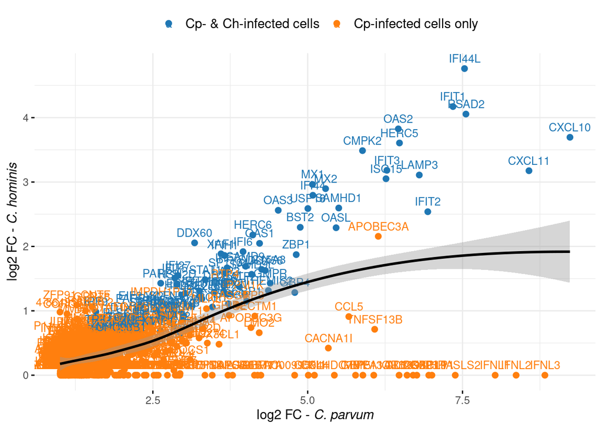

```r
library(tidyverse)
library(ggrepel)
library(plotly)
library(ggsci)
library(ggtext)
library(ggpubr)

Ch <- read_csv('tophits_upregul_Ch.csv')
Cp <- read_csv('tophits_upregul_Cp.csv')

merge_rank <- merge(Ch, Cp, all = TRUE)
merge_rank$logFC_Ch[is.na(merge_rank$logFC_Ch)] <- 0
merge_rank$logFC_Cp[is.na(merge_rank$logFC_Cp)] <- 0
merge_rank$adj.P.Val_Ch[is.na(merge_rank$adj.P.Val_Ch)] <- 1
merge_rank$adj.P.Val_Cp[is.na(merge_rank$adj.P.Val_Cp)] <- 1

Ch_signif <- subset(merge_rank, adj.P.Val_Ch <= .05 & logFC_Ch >= 1)
Cp_signif <- subset(merge_rank, adj.P.Val_Cp <= .05 & logFC_Cp >= 1)

merge_rank_filtered <- subset(merge_rank, (adj.P.Val_Ch <= .05 & logFC_Ch >= 1) | (adj.P.Val_Cp <= .05 & logFC_Cp >= 1)) %>%
  mutate(signif = case_when(
    adj.P.Val_Ch < .05 & adj.P.Val_Cp <.05 ~ 'Cp & Ch',
    adj.P.Val_Ch >= .05 & adj.P.Val_Cp <.05 ~ 'Cp',
    adj.P.Val_Ch < .05 & adj.P.Val_Cp >= .05 ~ 'Ch',
    TRUE ~ NA_character_)
  )

write_csv(merge_rank_filtered, 'merge_ranked_filtered_genes.csv')

merge_rank_filtered[merge_rank_filtered == 'Cp'] <- 'Cp-infected cells only'
merge_rank_filtered[merge_rank_filtered == 'Cp & Ch'] <- 'Cp- & Ch-infected cells'

rank_scatter <- ggscatter(
  data = merge_rank_filtered,
  x = 'logFC_Cp',
  y = 'logFC_Ch',
  color = 'signif',
  palette = 'd3',
  label = 'geneID',
  font.label = 10,
  repel = F,
  xlab = 'log2 FC - <i>C. parvum</i>',
  ylab = 'log2 FC - <i>C. hominis</i>',
  ggtheme = theme_minimal(base_size = 11)
) %>%
  ggpar(legend = 'top',
        legend.title = '',
        font.legend = c(11)) +
  geom_smooth(color = 'black') +
  theme(axis.title.x = element_markdown(),
        axis.title.y = element_markdown())

print(rank_scatter)
```

## 9.2 Pathways upregulation (MSigDB)

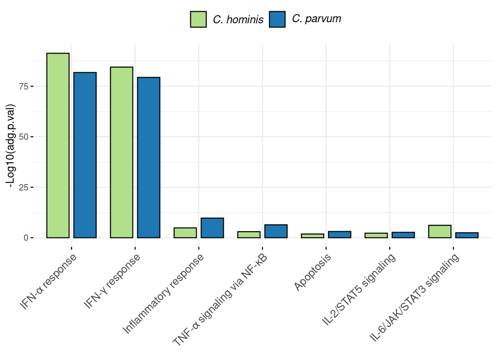

```r
library(multcomp)
library(tidyverse)
library(ggplot2)
library(RColorBrewer)
library(ggpubr)
library(rstatix)

MSigDB_dat <- read.csv(file = 'fig4_MSigDB_data.csv')
MSigDB_dat$logpval <- -log10(MSigDB_dat$Adjusted.P.value)
MSigDB_dat$Term <-
  as.factor(MSigDB_dat$Term) %>% ordered(
    levels = c(
      "IFN-α response",
      "IFN-γ response",
      "Inflammatory response",
      "TNF-α signaling via NF-κB",
      "Apoptosis",
      "IL-2/STAT5 signaling",
      "IL-6/JAK/STAT3 signaling"
    )
  )
MSigDB_dat$Strain <- as.factor(MSigDB_dat$Strain)

#Plot
MSigDB_plot <- ggbarplot(
  MSigDB_dat,
  'Term',
  'logpval',
  color = 'Black',
  fill = 'Strain',
  position = position_dodge(.85),
  xlab = FALSE,
  ylab = '-Log10(adg.p.val)',
  title = FALSE,
  ggtheme = theme_minimal(base_size = 11)
) %>%
  ggpar(
    legend = "top",
    legend.title = "",
    title = FALSE,
    orientation = "vertical",
    x.text.angle = 45,
    font.legend = c(11),
    font.xtickslab = c(11)
) +
  scale_fill_manual(labels = c(expression(paste(italic("C. hominis"))),
                               expression(paste(italic("C. parvum")))),
                               values = c("#b2df8a", "#1f78b4"))

print(MSigDB_plot)
```

# 10 Heatmaps and modules

Pearson correlation was used to cluster **946** differentially expressed genes, which were then represented as heatmap with the data scaled by Zscore for each row.

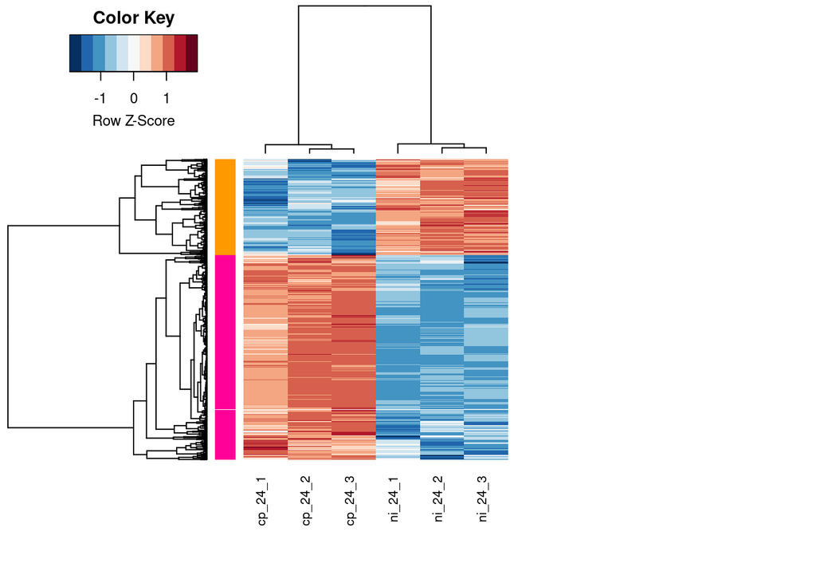

```r
library(tidyverse)
library(gplots)
library(RColorBrewer)
myheatcolors <- rev(brewer.pal(name="RdBu", n=11))
clustRows <- hclust(as.dist(1-cor(t(diffGenes), method="pearson")), method="complete") #cluster rows by pearson correlation
clustColumns <- hclust(as.dist(1-cor(diffGenes, method="spearman")), method="complete")
module.assign <- cutree(clustRows, k=2)
module.color <- rainbow(length(unique(module.assign)), start=0.1, end=0.9)
module.color <- module.color[as.vector(module.assign)]
heatmap.2(diffGenes,
          Rowv=as.dendrogram(clustRows),
          Colv=as.dendrogram(clustColumns),
          RowSideColors=module.color,
          col=myheatcolors, scale='row', labRow=NA,
          density.info="none", trace="none",
          cexRow=1, cexCol=1, margins=c(8,20))
```

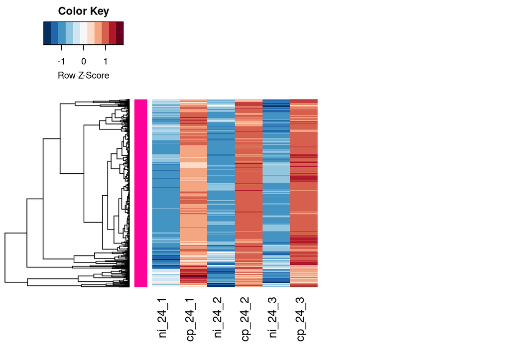

```r
modulePick <- 2
myModule_up <- diffGenes[names(module.assign[module.assign %in% modulePick]),]
hrsub_up <- hclust(as.dist(1-cor(t(myModule_up), method="pearson")), method="complete")

heatmap.2(myModule_up,
          Rowv=as.dendrogram(hrsub_up),
          Colv=NA,
          labRow = NA,
          col=myheatcolors, scale="row",
          density.info="none", trace="none",
          RowSideColors=module.color[module.assign%in%modulePick], margins=c(8,20))
```

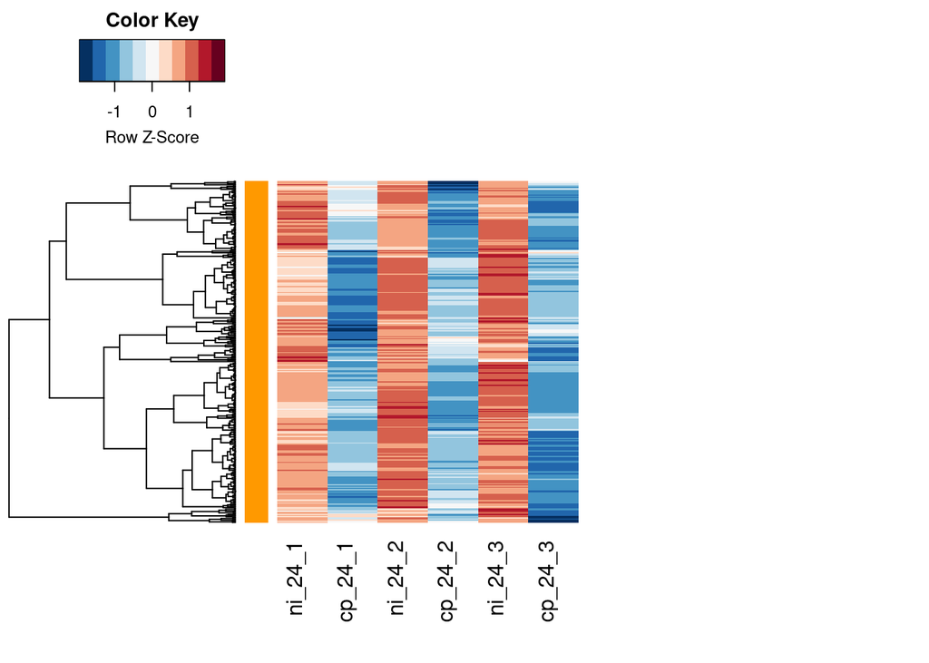

```r
modulePick <- 1
myModule_down <- diffGenes[names(module.assign[module.assign %in% modulePick]),]
hrsub_down <- hclust(as.dist(1-cor(t(myModule_down), method="pearson")), method="complete")

heatmap.2(myModule_down,
          Rowv=as.dendrogram(hrsub_down),
          Colv=NA,
          labRow = NA,
          col=myheatcolors, scale="row",
          density.info="none", trace="none",
          RowSideColors=module.color[module.assign%in%modulePick], margins=c(8,20))
```

# 11 GO enrichment

```r
library(tidyverse)
library(limma)
library(gplots) #for heatmaps
library(DT) #interactive and searchable tables of our GSEA results
library(GSEABase) #functions and methods for Gene Set Enrichment Analysis
library(Biobase) #base functions for bioconductor; required by GSEABase
library(GSVA) #Gene Set Variation Analysis, a non-parametric and unsupervised method for estimating variation of gene set enrichment across samples.
library(gprofiler2) #tools for accessing the GO enrichment results using g:Profiler web resources
library(clusterProfiler) # provides a suite of tools for functional enrichment analysis
library(msigdbr) # access to msigdb collections directly within R
library(enrichplot) # great for making the standard GSEA enrichment plots
gost.res_up <- gost(rownames(myModule_up), organism = "hsapiens", correction_method = "fdr")
gostplot(gost.res_up, interactive = T, capped = T) #set interactive=FALSE to get plot for publications
```

[interactive chart not shown]

```r
gost.res_down <- gost(rownames(myModule_down), organism = "hsapiens", correction_method = "fdr")
gostplot(gost.res_down, interactive = T, capped = T) #set interactive=FALSE to get plot for publications
```

[interactive chart not shown]

# 12 GSEA

```r
hs_gsea_c8 <-
  msigdbr(species = "Homo sapiens", # change depending on species your data came from
          category = "C8") %>% # choose your msigdb collection of interest
  dplyr::select(gs_name, gene_symbol) #just get the columns corresponding to signature name and gene symbols of genes in each signature

hs_gsea_h <-
  msigdbr(species = "Homo sapiens", # change depending on species your data came from
          category = "H") %>% # choose your msigdb collection of interest
  dplyr::select(gs_name, gene_symbol) #just get the columns corresponding to signature name and gene symbols of genes in each signature

# Now that you have your msigdb collections ready, prepare your data
# grab the dataframe you made in step3 script
# Pull out just the columns corresponding to gene symbols and LogFC for at least one pairwise comparison for the enrichment analysis
data.df.sub <- dplyr::select(data.df, geneID, LogFC)
data.gsea <- data.df.sub$LogFC
names(data.gsea) <- as.character(data.df.sub$geneID)
data.gsea <- sort(data.gsea, decreasing = TRUE)

# run GSEA using the 'GSEA' function from clusterProfiler
GSEA.res_H <- GSEA(data.gsea, TERM2GENE = hs_gsea_h, verbose = FALSE)
GSEA.df_H <- as_tibble(GSEA.res_H@result)

GSEA.res_C8 <- GSEA(data.gsea, TERM2GENE = hs_gsea_c8, verbose = FALSE)
GSEA.df_C8 <- as_tibble(GSEA.res_C8@result)

# view results as an interactive table

GSEAtable_H <- datatable(
  GSEA.df_H,
  extensions = c('KeyTable', "FixedHeader"),
  caption = 'Signatures enriched in hALI infected with Cp',
  options = list(
    keys = TRUE,
    searchHighlight = TRUE,
    pageLength = 10,
    lengthMenu = c("10", "25", "50", "100")
  )
) %>%
  formatRound(columns = c(2:10), digits = 2)

GSEAtable_C8 <- datatable(
  GSEA.df_C8,
  extensions = c('KeyTable', "FixedHeader"),
  caption = 'Signatures enriched in hALI infected with Cp',
  options = list(
    keys = TRUE,
    searchHighlight = TRUE,
    pageLength = 10,
    lengthMenu = c("10", "25", "50", "100")
  )
) %>%
  formatRound(columns = c(2:10), digits = 2)
```

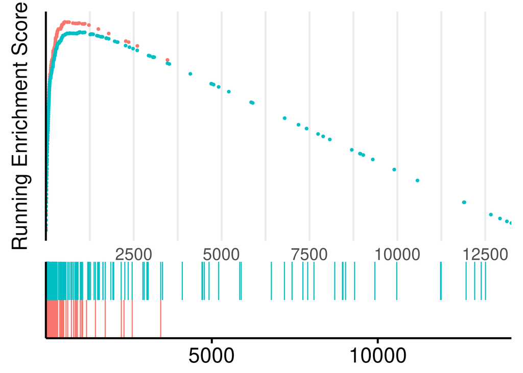

```r
library(ggpubr)

# create enrichment plots using the enrichplot package
gseaplot_up <- gseaplot2(
  GSEA.res_H,
  geneSetID = order(GSEA.df_H$enrichmentScore, decreasing = T)[1:2],
  pvalue_table = FALSE,
  title = NULL,
  ES_geom = "dot",
  subplots = c(1, 2),
  base_size = 20
) %>%
  ggpar(
    legend = "none",
    legend.title = "",
    title = FALSE,
    orientation = "vertical",
    font.legend = 15,
    font.ytickslab = 0,
    ticks = FALSE
  ) %>%
  print()
```

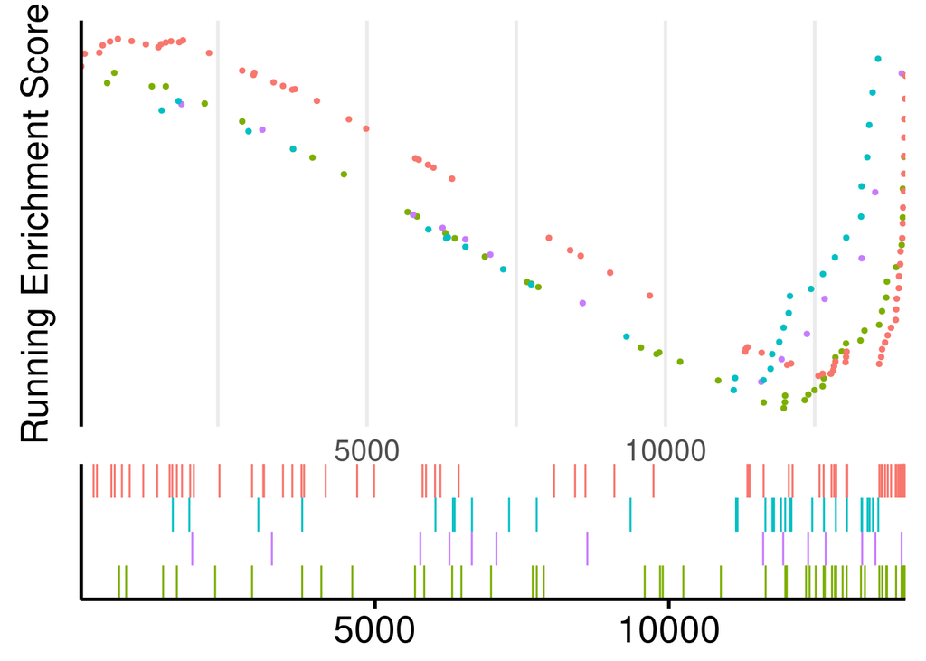

```r
#Downregulated processes
gseaplot_down <- gseaplot2(
  GSEA.res_C8,
  geneSetID = order(GSEA.df_C8$enrichmentScore, decreasing = F)[1:4],
  pvalue_table = FALSE,
  title = NULL,
  ES_geom = "dot",
  subplots = c(1, 2),
  base_size = 20
)  %>%
  ggpar(
    legend = "none",
    legend.title = "",
    title = FALSE,
    orientation = "vertical",
    font.legend = 15,
    font.ytickslab = 0,
    ticks = FALSE
  ) %>%
  print()
```

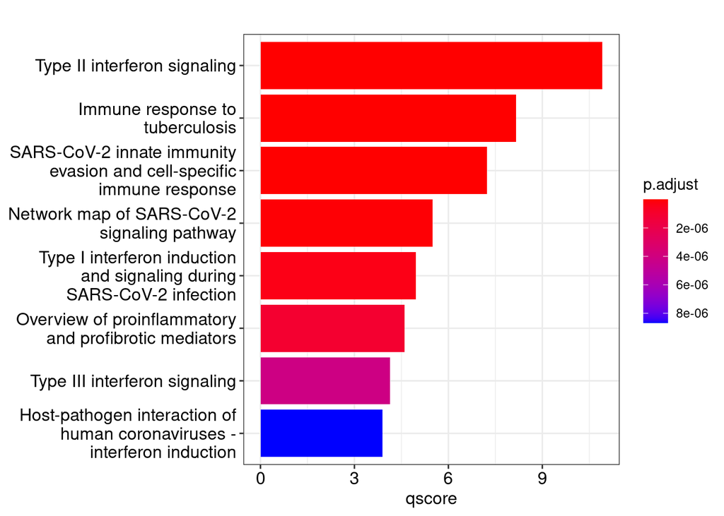

```r
library(DOSE)
library(ggridges)
library(org.Hs.eg.db)

#Create gene symbol list
symbols <- names(data.gsea)

# use mapIds method to obtain Entrez IDs
entrezid <- mapIds(org.Hs.eg.db, symbols, 'ENTREZID', 'SYMBOL')

geneList <- data.gsea
names(geneList) <- entrezid

de <- names(geneList)[abs(data.gsea) > 2]

edo <- enrichWP(de, organism = "Homo sapiens")
#edo@result <- edo@result[c(1,4,9,11,18),]

mutate(edo, qscore = -log(p.adjust, base = 20)) %>%
  barplot(x = "qscore")
```

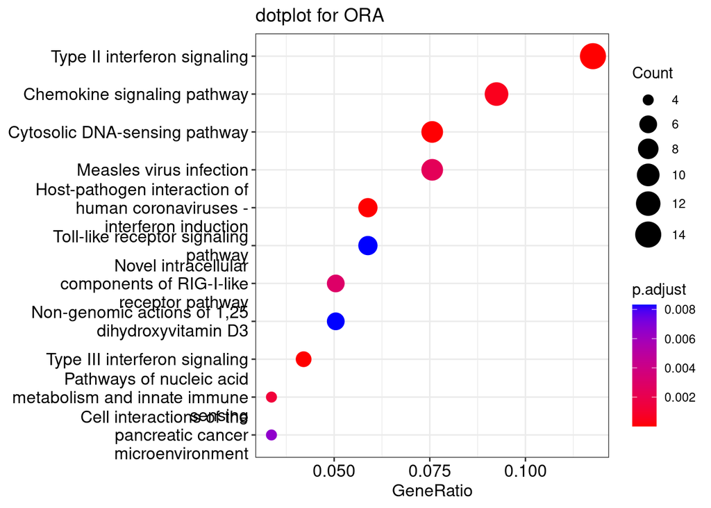

```r
edo2_WP <- gseWP(geneList, organism = "Homo sapiens")
edo2_KEGG <- gseKEGG(geneList)

edo_dot <- edo
edo_dot@result <- edo@result[c(1, 7, 8, 9, 10, 11, 12, 15, 16, 17, 18, 20), ]
dotplot(edo_dot, showCategory = 20) + ggtitle("dotplot for ORA")
```

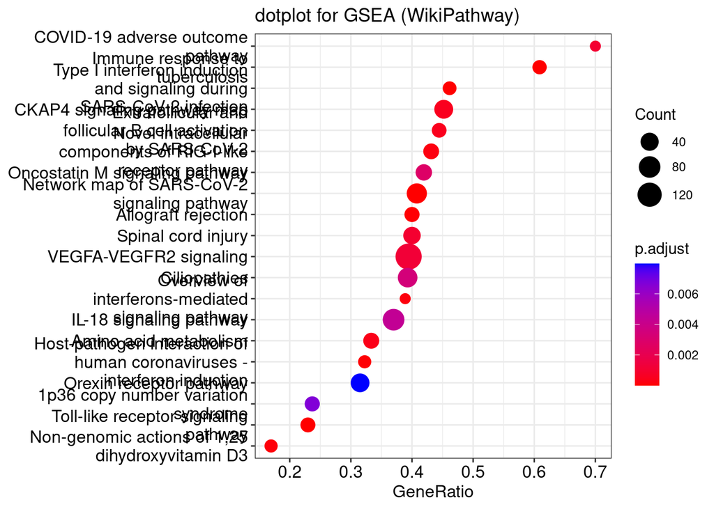

```r
edo2_WP@result <-
  edo2_WP@result[c(2, 4, 6, 8, 12, 18, 14, 17, 19, 20, 21, 23, 24, 25, 26, 32, 39, 29, 40, 41), ]
dotplot(edo2_WP, showCategory = 20) +
  ggtitle("dotplot for GSEA (WikiPathway)")
```

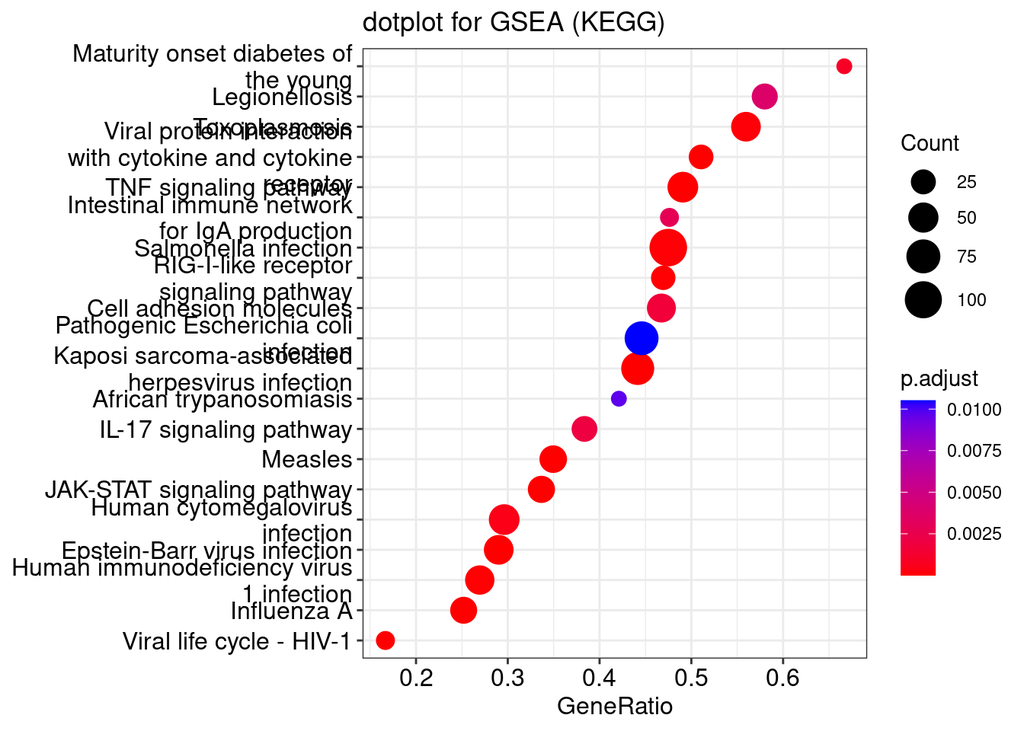

```r
edo2_KEGG@result <-
  edo2_KEGG@result[c(1, 3, 8, 9, 12, 13, 15, 16, 17, 18, 20, 21, 24, 27, 33, 35, 40, 45, 57, 58), ]
dotplot(edo2_KEGG, showCategory = 20) +
  ggtitle("dotplot for GSEA (KEGG)")
```

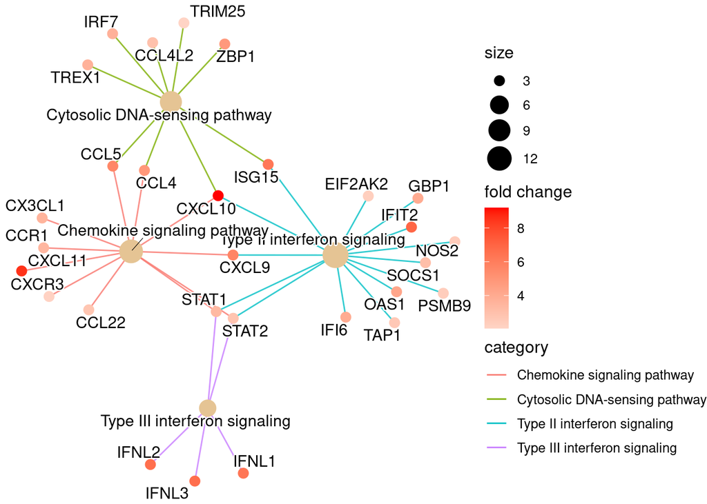

```r
## convert gene ID to Symbol
edox <- setReadable(edo, 'org.Hs.eg.db', 'ENTREZID')

edox2 <- edox
edox2@result <-
  edox@result[which(
    edox@result$Description %in% c(
      'Type II interferon signaling',
      'Type III interferon signaling',
      'Cytosolic DNA-sensing pathway',
      'Chemokine signaling pathway'
    )
  ),]

cnetplot <- cnetplot(
  edox2,
  foldChange = geneList,
  layout = 'fr',
  circular = F,
  colorEdge = TRUE,
  showCategory = 5,
  cex_label_gene = .8,
  cex_label_category = .8
) +
  theme(text = element_text(size = 12))

print(cnetplot)
```

# 13 Session info

The output from running ‘sessionInfo’ is shown below and details all packages and version necessary to reproduce the results in this report.

[session information not shown]